#### Section 1. Statistical Test

1.1 The Mann-Whitney U-Test was used to analyze the data set to compare number of entries with rain and number of entries in days without rain. A two-sided test was used to determine if the chance of randomly selecting samples from the data set would result in means this far apart. I doubled the p-value output to account for the two-sided nature. The p-value had to be less than or equal to the p-critical value of .05 to determine if there was a statistical difference in the means of the randomly selected samples. The two-sided test also helped to make sure that the test was not ‘one-way’ in it’s determination of significance, ie. someone may or may not ride the subway on a rainy day regardless of rain.

1.2 Mann-Whitney test works for this dataset because the data set is not normally distributed and it is a larger population set. It is a good test for comparison purposes to see if the means of the closely distributed data sets are similar or not similar enough to be of statistical significance relative to distribution shape, mean, median and sample size.

1.3 The results for the data set showed that Mean Entries with rain: 1105.44 vs Mean Entries without rain: 1090.28. With U-value 1924409167, and a p-value of 0.0249 and .0498 for two-tailed test. The p-value is less than or almost equal to the p-critical value of .05, we can conclude that the distributions of the data are statistically different. Consequently when the data was run locally, the means and U-value were identical however the p-value returned was actually lower, and returned .019309 and .038618 for one and two tailed tests respectively. Running this test on the updated version 2 data set produced results where the distributions differed significantly.

1.4 A p-value of .0498 for a two-tailed test is equal or below the p-critical value of 0.05 we can determine that distribution of entries is statistically different between the two, rainy and non-rainy, datasets. There appears to be some statistical difference for rainy and non-rainy days in the NYC subway ridership.

#### Section 2. Linear Regression

2.1 Initially gradient descent regression was used, also the bonus OLS model was used for analysis.

2.2 The input features selected for the linear regression were: “rain”, “precipi”, “Hour”, “maxtempi”. Using a dummy variable of “UNIT” to join the data on.

2.3 The features were selected for intuitive reasons, rain and precipitation level were obvious choices based on weather impacts. Hour was a factor to see how time impacted ridership and maxtempi captured the extremes on weather the best (either highest high on hot days and highest high on cold days).

2.4 The coefficients for the non-dummy features in the linear regression model are rain -315.43797693, precipi -233.33928452, Hour -155.29027806, maxtempi -153.96497977.

2.5 The r^2 for the given features above was 0.45909

2.6 Given an R^2 of .45909 we can infer that .459 of the variability around the regression line is explained by our model’s feature selections above. Based on the Histogram output below, the model appears to do a reasonably good job of explaining the independant variable as the residuals are normally centered around the expected output.

image:

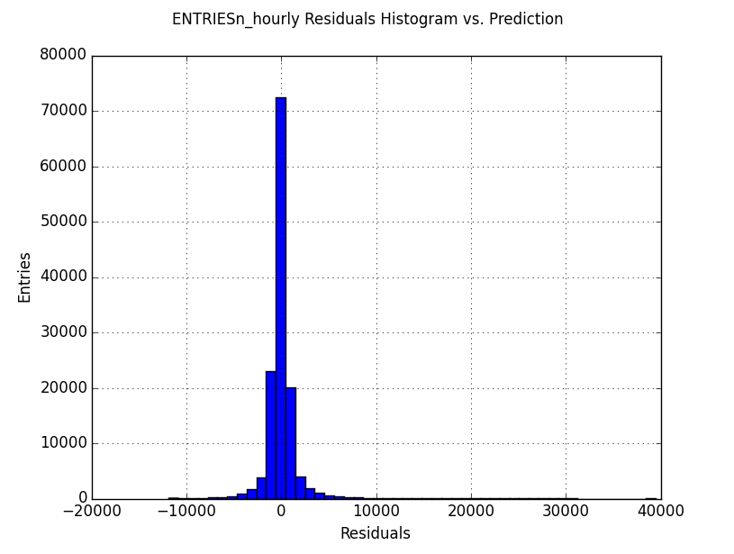

#### Section 3. Visualization

3.1 ##### Dual Histogram of ENTRIESn_hourly with rain and without rain image:

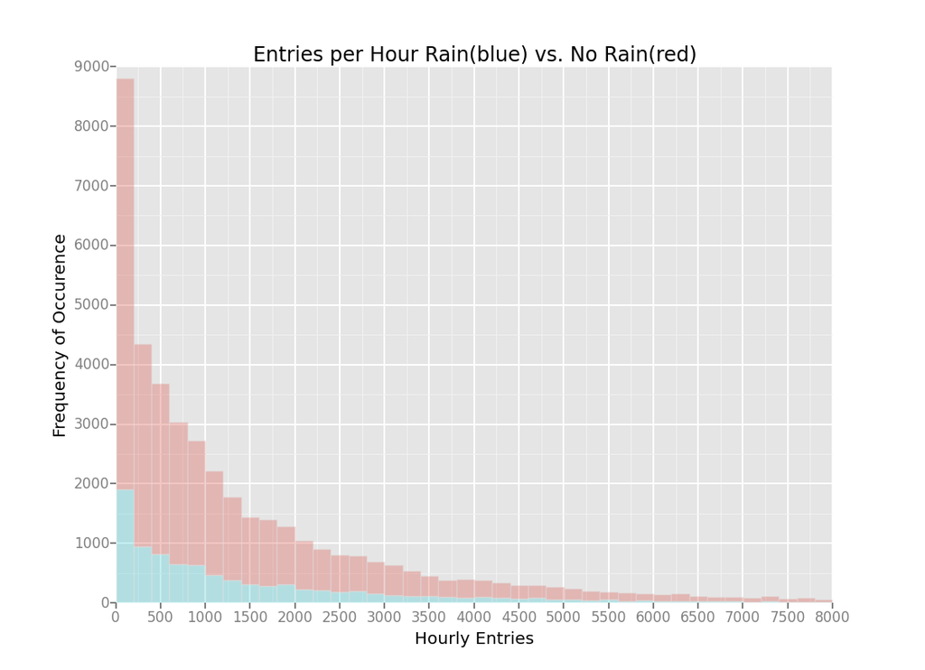

##### Chart showing Entries by Hour

image:

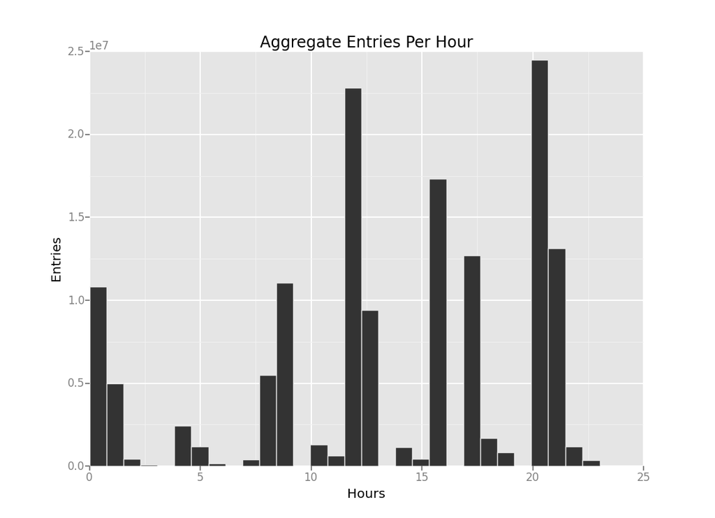

#### Section 4. Conclusion

4.1 Based on the Mann-Whitney Test we can determine see that the Mean Entries with rain is clearly higher than days without rain. So the conclusion would lead us to believe that there is enough initial statistical evidence that there is an increase in ridership on days with rain. Also if we were looking at the linear regression thetas we can see rain and precipi have a more meaningful impact on Entries over the others Hour and maxtempi.

4.2 Using the Mann-Whitney Test as an example, the p-value of 0.0498 is below the p-critical value of 0.05, this shows that the two distributions have meaningful differences. Also with mean entries without rain of 1090 vs. mean entries with rain of 1105, we can see there is definitely an increase in ridership on days with rain, especially given the size of the sample set.

#### Section 5. Reflection

5.1 The Data for the project was reasonably well represented and ordered, there weren’t any noticeable missing data points that weren’t taken care of. It was robust in terms of information across each of it’s points of data. There was some ambiguity surrounding what Entries and Exits truly represented or if they related to each other at all. The time data was gappy in that it was broken down in intervals that weren’t consistent across each subway “UNIT” that was being represented. The weather data seemed to be consistently portrayed and robust.

The shortcomings of the statistical analysis lay in the fact that a large amount of people consistently ride the subway no matter what the conditions outside are if there was a better way to strip out consistent ridership to get a better sense of rain conditions contributing to ridership we may be to show a more persistant relationship there. Linear models may not be the best model for finding causality in this data set and using the OLS method on the data sample in the udacity classroom i seemed be able to get slightly better results. I couldn’t duplicate these results on my own machine however as there seemed to be some problems with the matrix calculations when running the larger data set.